# What Moves the City? How COVID, Events and Weather Shaped Sydney’s Train Usage (2020–2025)

2025-07-22

# 1 Import Libraries

```r
knitr::opts_chunk$set(echo = TRUE, warning = FALSE, message = FALSE)

suppressPackageStartupMessages({
  library(dplyr)
  library(ggplot2)
  library(readr)
  library(lubridate)
  library(ggiraph)
  library(sf)
  library(rnaturalearth)
  library(rnaturalearthdata)
  library(stringr)
  library(vroom)
  library(zoo)
  library(knitr)
  library(kableExtra)
})
```

# 2 Data Loading

```r
sydney_weather <- read_csv("~/Downloads/sydney_weather.csv")

opal_2020_train <- read_csv("~/Downloads/opal_2020_train.csv")
opal_2021_train <- read_csv("~/Downloads/opal_2021_train.csv")
opal_2022_train <- read_csv("~/Downloads/opal_2022_train.csv")
opal_2023_train <- read_csv("~/Downloads/opal_2023_train.csv")
opal_2024_train <- read_csv("~/Downloads/opal_2024_train.csv")
opal_2025_train <- read_csv("~/Downloads/opal_2025_train.csv")
```

# 3 Executive Summary

# 4 Introduction

# 5 COVID Topic

- Show Opal data from 2020–2021 during lockdowns.
- Focus on CBD stations (e.g., Town Hall, Wynyard).
- Compare pre-COVID peaks vs lockdown silence. Message: When fear and policy collide, the city shuts down.

# 6 Vivid and Christmas

- Analyze spikes in evening entries during Vivid (May–June) and NYE (Dec 31).
- Use Circular Quay, Martin Place, and Town Hall as focal points.
- Compare normal weeks vs event weeks. Message: Events light up the city — literally and in the data.

# 7 Weather

- Contrast with COVID and event peaks. Message: Rain doesn’t cancel life — but it delays it.

## 7.1 Heatwaves and Floods

### 7.1.1 Heatwaves

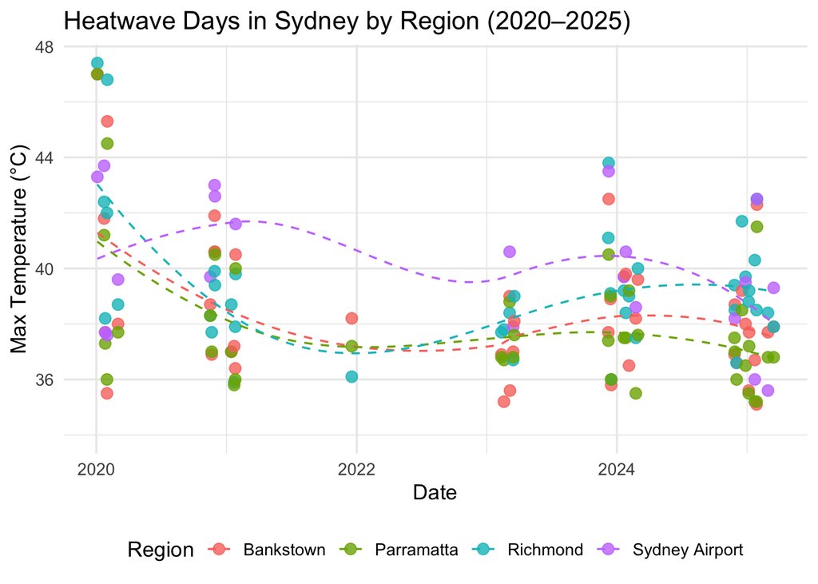

```r
# Step 1: Filter only needed columns and remove NAs
sydney_weather_filtered <- sydney_weather %>%
  select(Date, MaxTemp, region) %>%
  arrange(Date) %>%
  filter(!is.na(MaxTemp))  # This line removes rows where MaxTemp is NA

# Step 2: Create logical for HotDay
sydney_weather_filtered <- sydney_weather_filtered %>%
  mutate(HotDay = MaxTemp > 35)

# Step 3: rle-based streak detection
rle_hot <- rle(sydney_weather_filtered$HotDay)
hot_streaks <- inverse.rle(rle_hot)

# Step 4: Add streak group info safely
sydney_weather_filtered$HeatwaveGroup <- cumsum(c(TRUE, diff(hot_streaks) != 0))

# Step 5: Flag actual heatwave days (3+ hot days in a row)
sydney_weather_filtered$IsHeatwaveDay <- with(
  sydney_weather_filtered,
  ave(HotDay, HeatwaveGroup, FUN = function(x) all(x) & length(x) >= 3)
)

# Step 6: Keep only heatwave days
heatwave_days <- sydney_weather_filtered %>%
  filter(IsHeatwaveDay) %>%
  select(Date, MaxTemp, region, HeatwaveGroup)

ggplot(heatwave_days, aes(x = Date, y = MaxTemp, color = region)) +
  geom_point(size = 3, alpha = 0.8) +
  geom_smooth(method = "loess", se = FALSE, size = 0.6, linetype = "dashed") +
  scale_y_continuous(name = "Max Temperature (°C)", limits = c(34, NA)) +
  scale_x_date(name = "Date") +
  labs(title = "Heatwave Days in Sydney by Region (2020–2025)",
       color = "Region") +
  theme_minimal(base_size = 13) +
  theme(legend.position = "bottom")
```

### 7.1.2 Floods

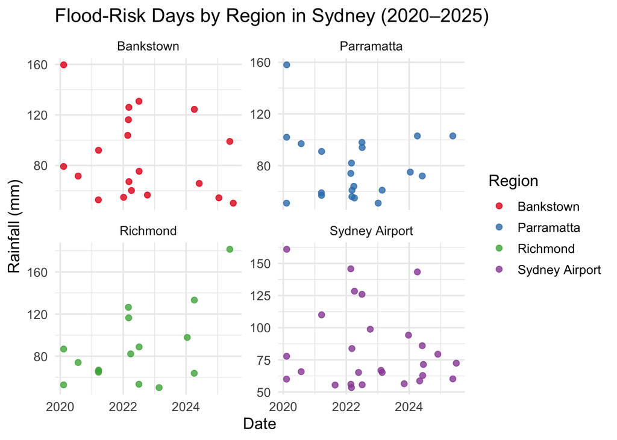

```r
# Step 1: Filter flood-risk days (Rainfall > 50mm)
flood_risk_days <- sydney_weather %>%
  filter(`Rainfall` > 50) %>%
  select(Date, `Rainfall`, region)

# Step 2: Arrange by date within each region
flood_risk_days <- flood_risk_days %>%
  arrange(Date, region)

# Step 3: Tag consecutive-day flood events with a FloodEvent ID
flood_risk_days <- flood_risk_days %>%
  group_by(region) %>%
  mutate(
    gap = c(0, as.numeric(diff(Date))),                # gap between days
    FloodEvent = cumsum(gap > 1) + 1                   # new group if gap > 1
  ) %>%
  select(-gap, -FloodEvent) %>%
  ungroup()

ggplot(flood_risk_days, aes(x = Date, y = Rainfall, color = region)) +
  geom_point(alpha = 0.8, size = 2) +
  facet_wrap(~ region, ncol = 2, scales = "free_y") +
  scale_color_brewer(palette = "Set1") +  # Optional: uses a nice color palette
  labs(
    title = "Flood-Risk Days by Region in Sydney (2020–2025)",
    x = "Date", y = "Rainfall (mm)",
    color = "Region"
  ) +
  theme_minimal(base_size = 13)
```

## 7.2 Train Usage During Extreme Weathers

### 7.2.1 Heatwaves

```r
# Combine all yearly train datasets into one
all_train_data <- bind_rows(
  opal_2020_train, opal_2021_train, opal_2022_train, opal_2023_train, opal_2024_train,
  opal_2025_train
)

# Ensure date column is in Date format
all_train_data <- all_train_data %>%
  mutate(trip_origin_date = as.Date(trip_origin_date))

# Add heatwave label to each row in train data
train_with_weather <- all_train_data %>%
  mutate(IsHeatwave = trip_origin_date %in% heatwave_days$Date)

# Group by heatwave or not, and summarise average Tap_Ons
heatwave_comparison <- train_with_weather %>%
  group_by(IsHeatwave) %>%
  summarise(
    avg_tap_ons = mean(Tap_Ons, na.rm = TRUE),
    median_tap_ons = median(Tap_Ons, na.rm = TRUE),
    count = n()
  )

print(heatwave_comparison)
```

```
## # A tibble: 2 × 4
##   IsHeatwave avg_tap_ons median_tap_ons  count
##   <lgl>            <dbl>          <dbl>  <int>
## 1 FALSE            6130.            600 456891
## 2 TRUE             6605.            700   9790
```

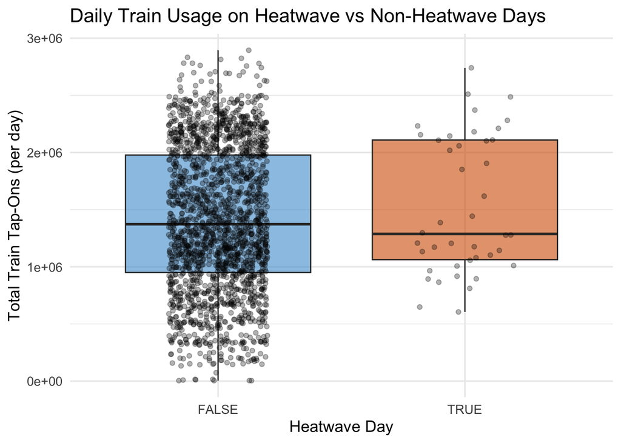

```r
daily_tap_ons <- train_with_weather %>%
  group_by(trip_origin_date, IsHeatwave) %>%
  summarise(daily_total = sum(Tap_Ons, na.rm = TRUE), .groups = "drop")

# Boxplot of daily total tap-ons
ggplot(daily_tap_ons, aes(x = IsHeatwave, y = daily_total, fill = IsHeatwave)) +
  geom_boxplot(outlier.shape = NA, alpha = 0.6) +
  geom_jitter(width = 0.2, alpha = 0.3, color = "black") +
  labs(
    title = "Daily Train Usage on Heatwave vs Non-Heatwave Days",
    x = "Heatwave Day",
    y = "Total Train Tap-Ons (per day)"
  ) +
  scale_fill_manual(values = c("FALSE" = "#4B9CD3", "TRUE" = "#D55E00")) +
  theme_minimal(base_size = 13) +
  theme(legend.position = "none")
```

### 7.2.2 Floods

```r
train_with_weather <- train_with_weather %>%
  mutate(IsFlood = trip_origin_date %in% flood_risk_days$Date)

flood_comparison <- train_with_weather %>%
  group_by(IsFlood) %>%
  summarise(
    avg_tap_ons = mean(Tap_Ons, na.rm = TRUE),
    median_tap_ons = median(Tap_Ons, na.rm = TRUE),
    count = n()
  )

print(flood_comparison)
```

```
## # A tibble: 2 × 4
##   IsFlood avg_tap_ons median_tap_ons  count
##   <lgl>         <dbl>          <dbl>  <int>
## 1 FALSE         6159.            600 457552
## 2 TRUE          5165.            500   9129
```

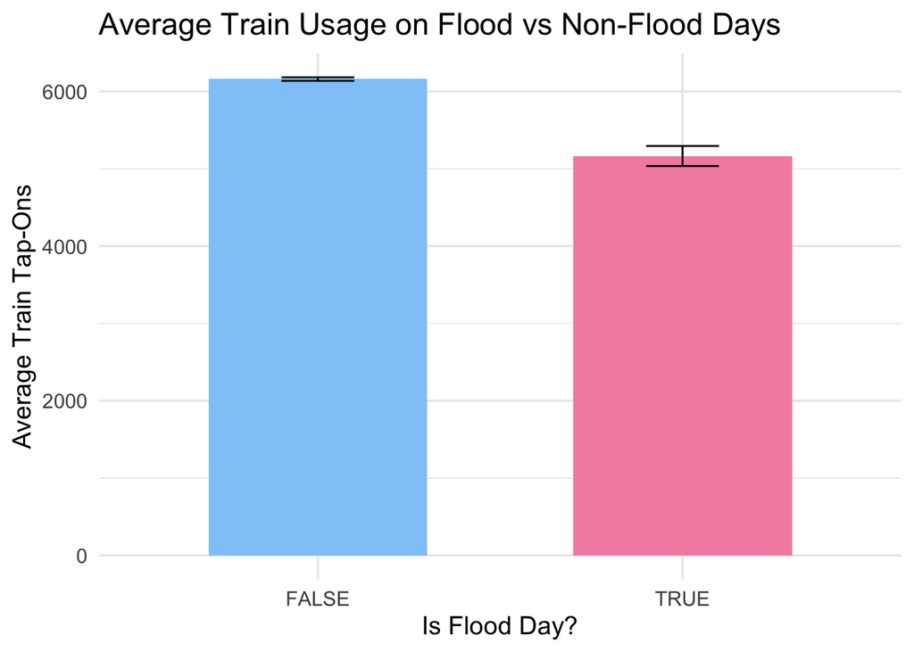

```r
flood_comparison <- train_with_weather %>%
  mutate(IsFlood = trip_origin_date %in% flood_risk_days$Date) %>%
  group_by(IsFlood) %>%
  summarise(
    avg_tap_ons = mean(Tap_Ons, na.rm = TRUE),
    sd = sd(Tap_Ons, na.rm = TRUE),
    n = n(),
    se = sd / sqrt(n)
  )

ggplot(flood_comparison, aes(x = IsFlood, y = avg_tap_ons, fill = IsFlood)) +
  geom_col(width = 0.6) +
  geom_errorbar(aes(ymin = avg_tap_ons - se, ymax = avg_tap_ons + se), width = 0.2) +
  labs(
    title = "Average Train Usage on Flood vs Non-Flood Days",
    x = "Is Flood Day?",
    y = "Average Train Tap-Ons"
  ) +
  scale_fill_manual(values = c("FALSE" = "#90CAF9", "TRUE" = "#F48FB1")) +
  theme_minimal(base_size = 14) +
  theme(legend.position = "none")
```

# 8 Comparative View: Which Force Disrupted the Most?

Create visual side-by-side comparisons: - % drop during COVID, during storms, and non-holiday baseline - % spike during events like Vivid - Show recovery speed — e.g. rain recovers in a day, COVID takes months - Possibly create a “disruption index” to quantify impact level and duration.

# 9 Conclusion: Moving Forward, Mindfully

- Reflect on what each disruption teaches:
- COVID = city shutdown, long recovery
- Events = fast joy, short-term crowding
- Weather = persistent but brief friction Call to action: Design smarter transit plans that adapt to multiple disruption types not just one.